# project2

```r
library(tidyverse)
library(tidytuesdayR)
library(ThemePark)
```

# Fun with functions

Janis Prak

## Part 1A: Exponential transformation

Write a function that computes the exponential of a number using the truncated series expansion. The function should take two arguments:

x: the number to be exponentiated

k: the number of terms to be used in the series expansion beyond the constant 1. The value of k is always ≥1.

For example, if 𝑘 =1, then the Exp function should return the number 1 +𝑥. If 𝑘 =2, then you should return the number 1 +𝑥 +𝑥2/2!.

Include at least one example of output using your function.

```r
Exp <- function(x, k) {
  ex <- 1
  for (i in 1:k){
    ex <- ex + ((x^i)/factorial(i))
  }
  return(ex)
}
```

```r
Exp(2,567)
```

```
## [1] 7.389056
```

## Part 1B: Sample mean and sample standard deviation

Next, write two functions called sample_mean() and sample_sd() that takes as input a vector of data of length 𝑁 and calculates the sample average and sample standard deviation for the set of 𝑁 observations.

Include at least one example of output using your functions.

```r
myvector <- c(4,5,67,1,3,4,5)
sample_mean <- function(x) {
    add <- 0
    for (i in x) {
      add <- add + i
    }
    return(add/length(x))
}

sample_mean(myvector)
```

```
## [1] 12.71429
```

```r
sample_sd <- function(x) {
    add <- 0
    for (i in x){
      add <- add + ((i-sample_mean(x))^2)
    }
    return(sqrt((1/(length(x)-1))*add))
}

sample_sd(myvector)
```

```
## [1] 23.97717
```

## Part 1C: Confidence intervals

```r
calculate_CI <- function(x, conf) {
    alpha <- 1 - conf
    degrees_freedom <- length(x) - 1
    t_score <- qt(p = alpha / 2, df = degrees_freedom, lower.tail = FALSE)

    lower_bound <- sample_mean(x)-(t_score*sample_sd(x)/sqrt(length(x)))
    upper_bound <- sample_mean(x)+(t_score*sample_sd(x)/sqrt(length(x)))
    ci<- c(lower_bound,upper_bound)

    return(ci)
}

calculate_CI(myvector, 0.95)
```

```
## [1] -9.46090 34.88947
```

```r
calculate_CI(myvector, 0.82)
```

```
## [1] -1.035687 26.464258
```

```r
#test
dat <- data.frame(x = myvector)
fit <- lm(myvector ~ 1, dat)

# Calculate a 95% confidence interval
confint(fit, level = 0.95)
```

```
##               2.5 %   97.5 %
## (Intercept) -9.4609 34.88947
```

```r
#test #2
dat <- data.frame(x = myvector)
fit <- lm(myvector ~ 1, dat)

# Calculate a 95% confidence interval
confint(fit, level = 0.82)
```

```
##                   9 %     91 %
## (Intercept) -1.035687 26.46426
```

# Part 2: Wrangling data

```r
library(here)
if (!file.exists(here("data", "tuesdata_rainfall.RDS"))) {
    tuesdata <- tidytuesdayR::tt_load("2020-01-07")
    rainfall <- tuesdata$rainfall
    temperature <- tuesdata$temperature

    # save the files to RDS objects
    saveRDS(tuesdata$rainfall, file = here("data", "tuesdata_rainfall.RDS"))
    saveRDS(tuesdata$temperature, file = here("data", "tuesdata_temperature.RDS"))
}
```

```r
rainfall <- readRDS(here("data", "tuesdata_rainfall.RDS"))
temperature <- readRDS(here("data", "tuesdata_temperature.RDS"))

glimpse(rainfall)
```

```
## Rows: 179,273
## Columns: 11
## $ station_code <chr> "009151", "009151", "009151", "009151", "009151", "009151…
## $ city_name    <chr> "Perth", "Perth", "Perth", "Perth", "Perth", "Perth", "Pe…
## $ year         <dbl> 1967, 1967, 1967, 1967, 1967, 1967, 1967, 1967, 1967, 196…
## $ month        <chr> "01", "01", "01", "01", "01", "01", "01", "01", "01", "01…
## $ day          <chr> "01", "02", "03", "04", "05", "06", "07", "08", "09", "10…
## $ rainfall     <dbl> NA, NA, NA, NA, NA, NA, NA, NA, NA, NA, NA, NA, NA, NA, N…
## $ period       <dbl> NA, NA, NA, NA, NA, NA, NA, NA, NA, NA, NA, NA, NA, NA, N…
## $ quality      <chr> NA, NA, NA, NA, NA, NA, NA, NA, NA, NA, NA, NA, NA, NA, N…
## $ lat          <dbl> -31.96, -31.96, -31.96, -31.96, -31.96, -31.96, -31.96, -…
## $ long         <dbl> 115.79, 115.79, 115.79, 115.79, 115.79, 115.79, 115.79, 1…
## $ station_name <chr> "Subiaco Wastewater Treatment Plant", "Subiaco Wastewater…
```

```r
glimpse(temperature)
```

```
## Rows: 528,278
## Columns: 5
## $ city_name   <chr> "PERTH", "PERTH", "PERTH", "PERTH", "PERTH", "PERTH", "PER…
## $ date        <date> 1910-01-01, 1910-01-02, 1910-01-03, 1910-01-04, 1910-01-0…
## $ temperature <dbl> 26.7, 27.0, 27.5, 24.0, 24.8, 24.4, 25.3, 28.0, 32.6, 35.9…
## $ temp_type   <chr> "max", "max", "max", "max", "max", "max", "max", "max", "m…
## $ site_name   <chr> "PERTH AIRPORT", "PERTH AIRPORT", "PERTH AIRPORT", "PERTH …
```

```r
rainfall <- rainfall %>%
  drop_na()%>%
  mutate(date = ymd(paste0(year,"-",month,"-",day)),
         city_name = toupper(city_name))%>%
  select(!c(month,day))

raintemp <- inner_join(rainfall, temperature, by = c("city_name", "date"))
raintemp
```

```
## # A tibble: 83,964 × 13
##    station_code city_name  year rainfall period quality   lat  long station_name
##    <chr>        <chr>     <dbl>    <dbl>  <dbl> <chr>   <dbl> <dbl> <chr>
##  1 009151       PERTH      1967      2.8      1 Y       -32.0  116. Subiaco Was…
##  2 009151       PERTH      1967      2.8      1 Y       -32.0  116. Subiaco Was…
##  3 009151       PERTH      1967      4.8      1 Y       -32.0  116. Subiaco Was…
##  4 009151       PERTH      1967      4.8      1 Y       -32.0  116. Subiaco Was…
##  5 009151       PERTH      1967      5.8      1 Y       -32.0  116. Subiaco Was…
##  6 009151       PERTH      1967      5.8      1 Y       -32.0  116. Subiaco Was…
##  7 009151       PERTH      1967     16        1 Y       -32.0  116. Subiaco Was…
##  8 009151       PERTH      1967     16        1 Y       -32.0  116. Subiaco Was…
##  9 009151       PERTH      1967      1        1 Y       -32.0  116. Subiaco Was…
## 10 009151       PERTH      1967      1        1 Y       -32.0  116. Subiaco Was…
## # ℹ 83,954 more rows
## # ℹ 4 more variables: date <date>, temperature <dbl>, temp_type <chr>,
## #   site_name <chr>
```

# Part 3: Data visualization

## Part 3A: Plotting temperature data over time

```r
p <- raintemp %>%
  filter(year >= 2014)%>%
  group_by(city_name,year)%>%
  summarize(
    maxtemp = max(temperature),
    mintemp = min(temperature)
  )
```

```
## `summarise()` has regrouped the output.
## ℹ Summaries were computed grouped by city_name and year.
## ℹ Output is grouped by city_name.
## ℹ Use `summarise(.groups = "drop_last")` to silence this message.
## ℹ Use `summarise(.by = c(city_name, year))` for per-operation grouping
##   (`?dplyr::dplyr_by`) instead.
```

[figure not shown]

```r
p %>%
  ggplot(aes(x = year))+
  geom_line(aes(y = maxtemp, color = "maxtemp"))+
  geom_line(aes(y = mintemp, color = "mintemp"))+
  facet_wrap(~ city_name, nrow = 2, axes = "all")+
  labs(
    title = "Maximum and Minimum Temperature in Each City per Year",
    subtitle = "Maximum and minimum temperatures remain steady through the years.",
    x = "Year",
    y = "Temperature(˚C)",
    color = "",
    caption = "SOURCE: #tidytuesday project"
  )+
  scale_color_manual(
      values = c("hotpink", "purple"),           # Custom colors
    labels = c("Maximum temperature", "Minimum temperature")
  )+
  theme_starwars()+
  theme(axis.text = element_text(size = 10, angle = 45, hjust = 1),
        plot.title = element_text(size = 15),
        panel.grid.major = element_line(color = "gray30", linewidth = 0.5),
        panel.grid.minor = element_line(color = "gray20", linewidth = 0.25)
        )
```

## Part 3B: Plotting rainfall over time

I began with the error messages if the inputted data doesn’t exist in the data to stop any errors. Then, I filtered the data by city and year, and then plotted the graph. Lastly, I added aesthetic choices to make the graph more reader friendly.

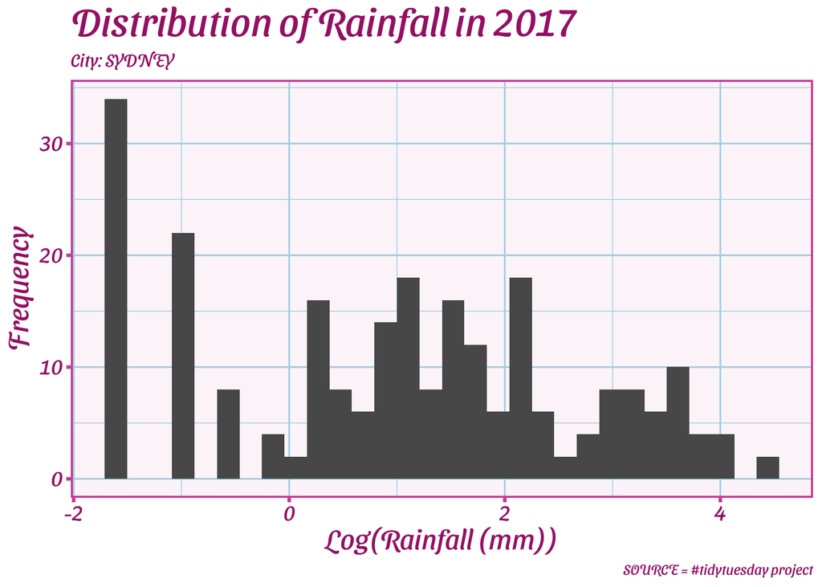

```r
#remotes::install_github("MatthewBJane/ThemePark")


rainplot <- function(cty, yr) {
  if (!cty %in% raintemp$city_name){
    stop("City does not exist in dataset.")
  }
  if (!yr %in% raintemp$year){
    stop("Year does not exist in the dataset.")
  }
  raintemp%>%
    filter(city_name == cty, year == yr)%>%
    ggplot(aes(log(rainfall)))+
    geom_histogram(bins = 30)+
    labs(
      title = paste0("Distribution of Rainfall in ",yr),
      subtitle = paste0("City: ", cty),
      x = "Log(Rainfall (mm))",
      y = "Frequency",
      caption = "SOURCE = #tidytuesday project"
    ) +
    theme_barbie()+
    theme(
      panel.grid.major = element_line(color = "lightblue", linewidth = 0.5),
      panel.grid.minor = element_line(color = "lightblue", linewidth = 0.25)
    )


}

rainplot(cty = "SYDNEY", yr = 2017)
```

# Part 4: Apply functions and plot

## Part 4A: Tasks

```r
rain_df <- raintemp%>%
  filter(year >= 2014)%>%
  group_by(year, city_name)%>%
  summarize(
    average = sample_mean(rainfall),
    stddev = sample_sd(rainfall),
    lower_bound = calculate_CI(rainfall,0.95)[1],
    upper_bound = calculate_CI(rainfall,0.95)[2]
  )
```

```
## `summarise()` has regrouped the output.
## ℹ Summaries were computed grouped by year and city_name.
## ℹ Output is grouped by year.
## ℹ Use `summarise(.groups = "drop_last")` to silence this message.
## ℹ Use `summarise(.by = c(year, city_name))` for per-operation grouping
##   (`?dplyr::dplyr_by`) instead.
```

```r
rain_df
```

```
## # A tibble: 30 × 6
## # Groups:   year [6]
##     year city_name average stddev lower_bound upper_bound
##    <dbl> <chr>       <dbl>  <dbl>       <dbl>       <dbl>
##  1  2014 BRISBANE     3.84  12.3         2.99        4.69
##  2  2014 CANBERRA     1.57   4.84        1.22        1.92
##  3  2014 MELBOURNE    3.83   5.24        3.18        4.49
##  4  2014 PERTH        7.87  12.8         5.90        9.85
##  5  2014 SYDNEY       2.49   6.47        2.01        2.96
##  6  2015 BRISBANE     6.17  22.7         4.53        7.82
##  7  2015 CANBERRA     1.51   5.16        1.13        1.89
##  8  2015 MELBOURNE    4.06   5.72        3.31        4.82
##  9  2015 PERTH        7.80  10.1         6.12        9.47
## 10  2015 SYDNEY       3.67  11.5         2.83        4.50
## # ℹ 20 more rows
```

## Part 4B: Tasks

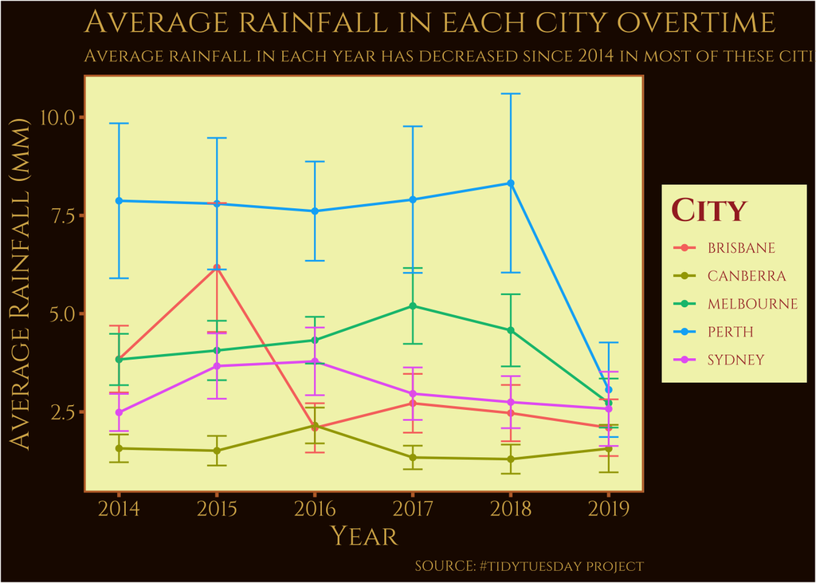

```r
rain_df%>%
  ggplot(aes(x = year, y = average, color = city_name))+
  geom_point()+
  geom_line(linewidth = .75)+
  geom_errorbar(aes(ymin = lower_bound, ymax = upper_bound), width = 0.2)+
  labs(
    title = ("Average rainfall in each city overtime"),
    subtitle = "Average rainfall in each year has decreased since 2014 in most of these cities.",
    x = "Year",
    y = "Average Rainfall (mm)",
    color = "City",
    caption = "SOURCE: #tidytuesday project"
  )+
  theme_gameofthrones()+
  theme(
    legend.text = element_text(color = "brown"),
    legend.title = element_text(color = "brown", face = "bold"),
    plot.title = element_text(size = 20)
  )
```